# Part II - Ford GoBike System Data

## by Long Le Trung (Brian)

## Investigation Overview

The primary goals of this presentation are:

n this investigation, I wanted to take a look at behavior of Users by durations, age, time, location and how far they go usually.

## Dataset Overview

This dataset serves as a rich resource for understanding how users interact with the bike-sharing service, enabling targeted strategies to enhance user experience and service efficiency.

## (Visualization 1)

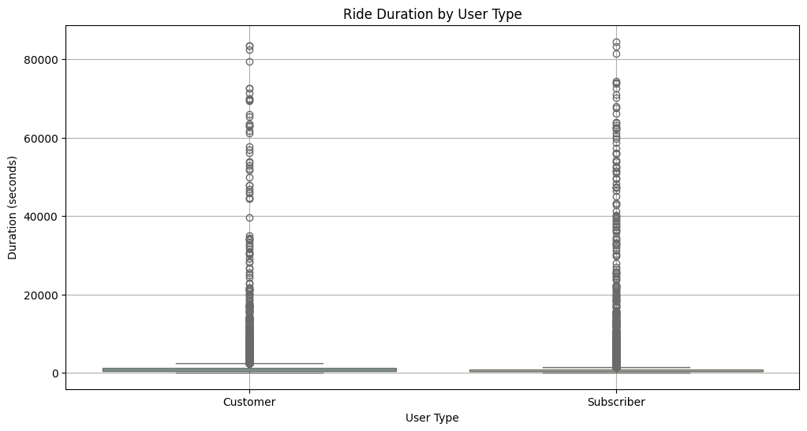

# Visualization 2: Average Trip Duration by Age Group

This bar chart displays the average duration of trips (in seconds) segmented by age group. Each bar represents the mean duration for a specific age category, showing which age groups tend to take longer trips on average.

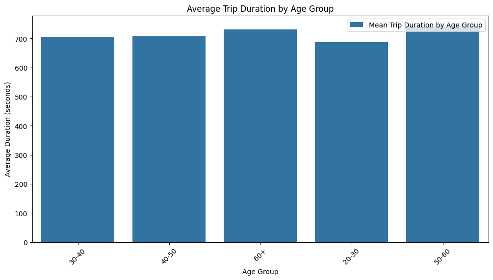

## Visualization 3: Trip Distance Distribution

This histogram illustrates the frequency of different trip distances in meters. The distribution gives insight into common trip lengths, with the majority of trips falling within a specific range. The curve also shows a smoothed probability density, highlighting the most typical distances.

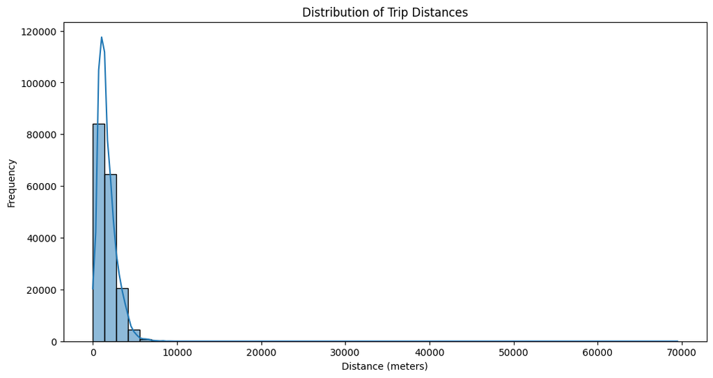

## Visualization 4: Number of Rides by Time of Day

This count plot shows the distribution of rides throughout each hour of the day. It provides a clear view of peak and low-activity hours, which can indicate commuter patterns or popular times for bike usage.

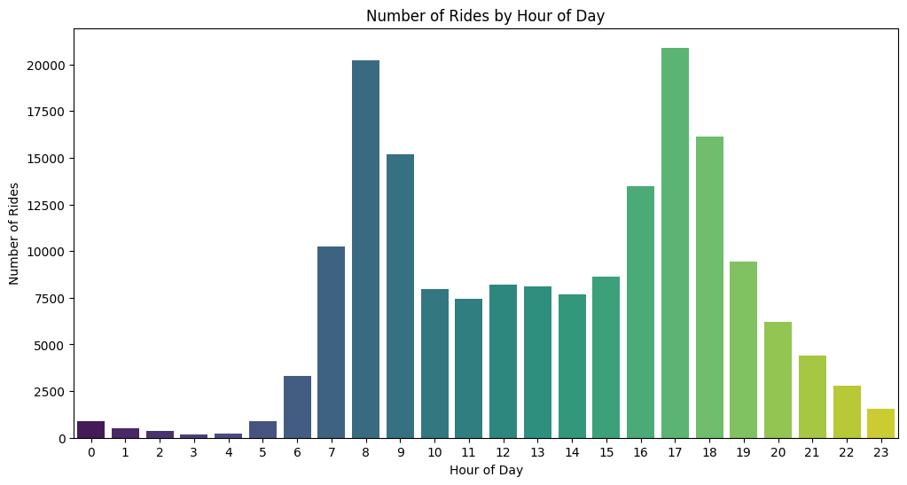

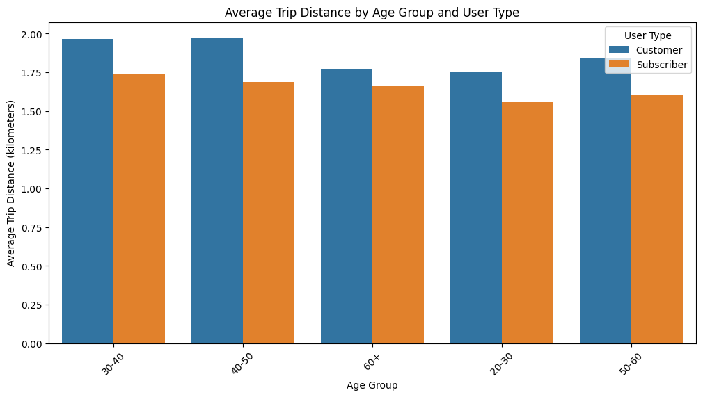